# Living Donor Liver Transplant for Hepatocellular Carcinoma in the Post ‘Median Meld Minus 3’ Era

R. LOH, R. HASS, B. LAZAREVIC, M. WINTE, J. CIVAN, D. THOLEY

2024-05-13

## Data extraction

The following variables were selected from the Liver database due to substantive interest. The national STAR files have more information about each variable

### Full list of variables extracted

Variables (see UNOS for abbreviations): ABO, AGE, BMI_CALC, COD, COD_WL, COD2, COD3, COMPOSITE_DEATH_DATE, DAYSWAIT_CHRON, DEATH_DATE, DGN_TCR, DGN_TCR2, DIAG, DON_TY, EDUCATION, END_DATE, END_STAT, ETHCAT, EXC_DIAG_ID, EXC_HCC, FINAL_MELD_PELD_LAB_SCORE, FINAL_SERUM_CREAT, FUNC_STAT_TRR, GENDER, GRF_STAT, GSTATUS, HCC_DIAG, HCC_DIAGNOSIS_TCR, HCC_EVER_APPR, LOS, MELD_DIFF_REASON_CD, MELD_PELD_LAB_SCORE, MULTIORG, NUM_PREV_TX, PRI_PAYMENT_CTRY_TRR, PRI_PAYMENT_TRR,PRVTXDIF, PSTATUS, PTIME, REGION, REM_CD, TRR_ID_CODE, TX_DATE, TX_YEAR, TX_PROCEDUR_TY

#### Exclusion criteria (any of the following):

- Re-transplantation
- Multiorgan transplant
- Acute liver failure
- Cholangiocarcinoma

### Recoded Variables:

- EDUCATION was re-coded as 1 = None - GED, 2 = College, 3 = Post Grad
- ETHCAT was re-coded as 1 = White, 2 = non-Hispanic Black, 3 = Hispanic / Latino, 4 = Asian, 5 = Other
- PRI_PAYMENT_TRR (insurance) re-coded as 1 = Private, 2 = Public, 3 = Other. Only Private v. Public was retained for analysis

## Table 1

Demographic and Clincal Variables for Donor Types

|  | Deceased (N=22383) | Living (N=616) | Overall (N=22999) |
| --- | --- | --- | --- |
| Era |  |  |  |
| Pre | 17848 (79.7%) | 400 (64.9%) | 18248 (79.3%) |
| Post | 4535 (20.3%) | 216 (35.1%) | 4751 (20.7%) |
| RECIPIENT AGE (YRS) |  |  |  |
| Mean (SD) | 59.9 (7.28) | 59.0 (9.25) | 59.9 (7.34) |
| Median [Min, Max] | 60.0 [18.0, 82.0] | 60.0 [18.0, 76.0] | 60.0 [18.0, 82.0] |
| Race / Ethnicity |  |  |  |
| White | 14702 (65.7%) | 459 (74.5%) | 15161 (65.9%) |
| Asian | 1591 (7.1%) | 37 (6.0%) | 1628 (7.1%) |
| Hisp/Lat | 3895 (17.4%) | 92 (14.9%) | 3987 (17.3%) |
| Non Hisp Black | 1909 (8.5%) | 20 (3.2%) | 1929 (8.4%) |
| Other | 286 (1.3%) | 8 (1.3%) | 294 (1.3%) |
| Calculated Recipient BMI |  |  |  |
| Mean (SD) | 29.0 (5.35) | 28.0 (5.04) | 28.9 (5.34) |
| Median [Min, Max] | 28.4 [15.2, 63.1] | 27.4 [16.3, 44.4] | 28.4 [15.2, 63.1] |
| Missing | 1 (0.0%) | 0 (0%) | 1 (0.0%) |
| WL MELD/PELD Lab Score at Most Recent Time |  |  |  |
| Mean (SD) | 15.0 (8.46) | 13.6 (5.52) | 15.0 (8.40) |
| Median [Min, Max] | 13.0 [6.00, 68.0] | 13.0 [6.00, 34.0] | 13.0 [6.00, 68.0] |
| Missing | 8 (0.0%) | 1 (0.2%) | 9 (0.0%) |
| WL SERUM CREATININE AT REMOVAL |  |  |  |
| Mean (SD) | 1.08 (0.679) | 0.932 (0.439) | 1.07 (0.674) |
| Median [Min, Max] | 0.900 [0, 13.8] | 0.870 [0.280, 6.70] | 0.900 [0, 13.8] |
| Missing | 9 (0.0%) | 1 (0.2%) | 10 (0.0%) |
| GENDER |  |  |  |
| Male | 17491 (78.1%) | 423 (68.7%) | 17914 (77.9%) |
| Female | 4892 (21.9%) | 193 (31.3%) | 5085 (22.1%) |
| Payor Type |  |  |  |
| Private | 11202 (50.0%) | 378 (61.4%) | 11580 (50.4%) |
| Public | 11181 (50.0%) | 238 (38.6%) | 11419 (49.7%) |
| Level of Education |  |  |  |
| None to GED | 10802 (48.3%) | 235 (38.1%) | 11037 (48.0%) |
| College | 8713 (38.9%) | 260 (42.2%) | 8973 (39.0%) |
| Post Grad | 1439 (6.4%) | 68 (11.0%) | 1507 (6.6%) |
| Missing | 1429 (6.4%) | 53 (8.6%) | 1482 (6.4%) |
| Region |  |  |  |
| Central | 1529 (6.8%) | 22 (3.6%) | 1551 (6.7%) |
| Midwest | 3413 (15.2%) | 130 (21.1%) | 3543 (15.4%) |
| Northeast | 5124 (22.9%) | 290 (47.1%) | 5414 (23.5%) |
| South | 7935 (35.5%) | 92 (14.9%) | 8027 (34.9%) |
| Western | 4382 (19.6%) | 82 (13.3%) | 4464 (19.4%) |

## Interrupted Time Series aka segmented regression

The purpose of this analysis was to test whether the time-series trajectory changed in 2015 and 2019 for live donor patients and deceased donor patients separately.

Because counts may be correlated with prior year counts (autocorrelation) we also examined the autocorrelation of residuals in a basic time series and segmented regression for LD and DD transplants. In both cases (below) introducing autocorrelations in the model did not change results.

### Table of transplant counts per year per donor type

| Transplant Year | Deceased Donor | Live Donor |
| --- | --- | --- |
| 2005 | 633 | 18 |
| 2006 | 874 | 24 |
| 2007 | 927 | 29 |
| 2008 | 1223 | 22 |
| 2009 | 1257 | 18 |
| 2010 | 1256 | 37 |
| 2011 | 1404 | 22 |
| 2012 | 1489 | 32 |
| 2013 | 1436 | 32 |
| 2014 | 1520 | 30 |
| 2015 | 1587 | 34 |
| 2016 | 1507 | 44 |
| 2017 | 1644 | 36 |
| 2018 | 1661 | 42 |
| 2019 | 1489 | 64 |
| 2020 | 1293 | 54 |
| 2021 | 1128 | 66 |
| 2022 | 786 | 39 |

### Living donor regression model

Regression Coefficients and 95% Confidence Intervals for The Living Donor Time-series Model

| Variable | Estimate | Lower 95% CI | Upper 95% CI |
| --- | --- | --- | --- |
| (Intercept) | 21.0 | 12.13 | 29.87 |
| time | 1.2 | -0.46 | 2.86 |
| int1 | 3.2 | -17.29 | 23.69 |
| time_int1 | 0.4 | -6.55 | 7.35 |
| int2 | 30.1 | 7.73 | 52.47 |
| time_int2 | -7.9 | -17.44 | 1.64 |

#### Residual and Autocorrelation plots for LDLT

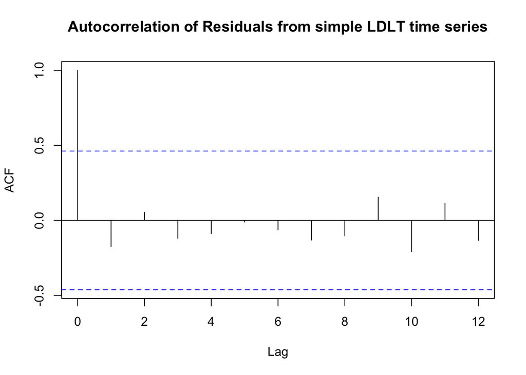

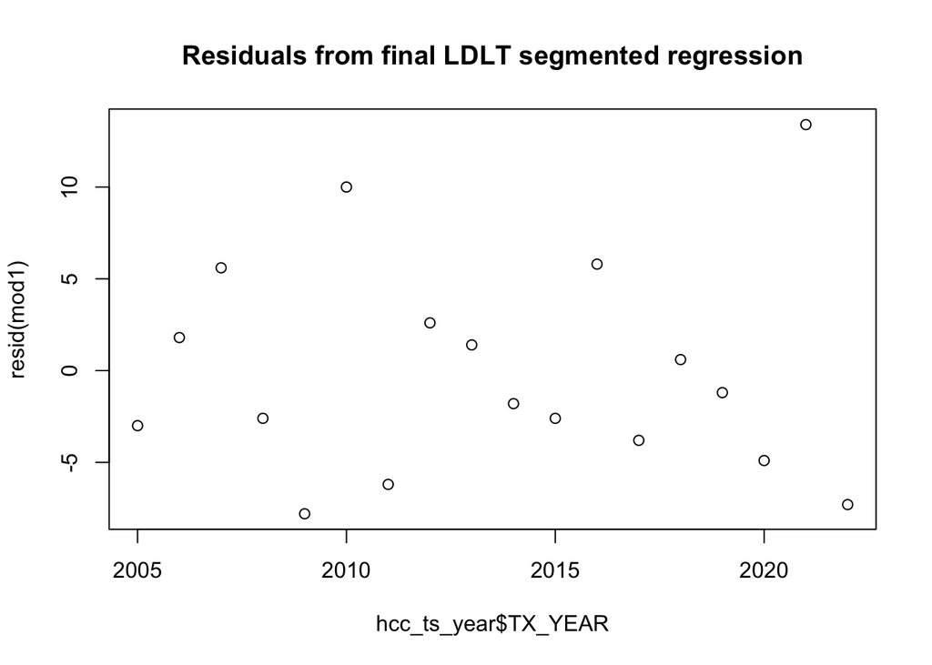

### Figure 1 - Living Donor Liver Transplant Rates in Patients with HCC MELD exception over Pre-MMT era 1, Pre-MMT era 2, and MMT eras

*Note: straight line represents the null hypothesis that trajectories did not change with policy changes*

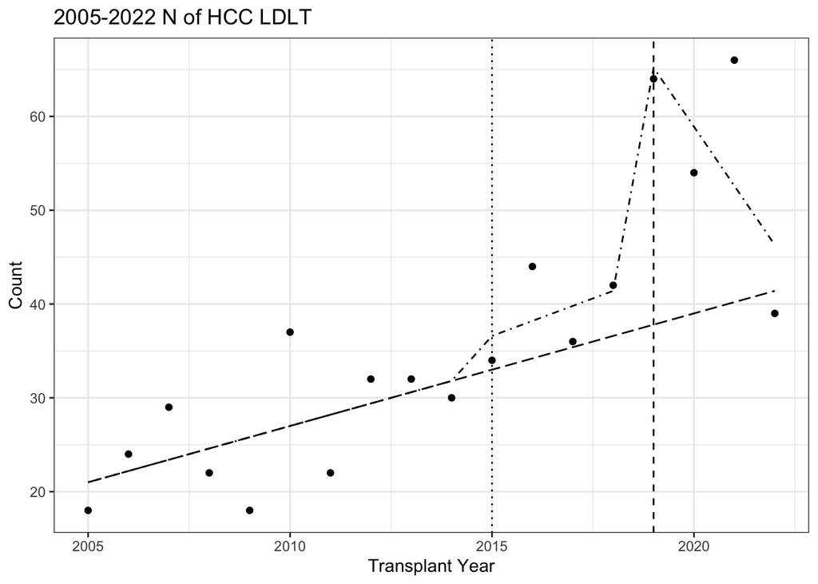

### Deceased donor regression model

Same model checking as before

[figure not shown]

Regression Coefficients and 95% Confidence Intervals for The Deceased Donor Time-series Model

| Variable | Estimate | Lower 95% CI | Upper 95% CI |
| --- | --- | --- | --- |
| (Intercept) | 785.47 | 667.73 | 903.21 |
| time | 92.54 | 70.48 | 114.59 |
| int1 | -108.33 | -380.46 | 163.80 |
| time_int1 | -56.64 | -148.90 | 35.62 |
| int2 | 88.90 | -208.22 | 386.02 |
| time_int2 | -263.30 | -389.99 | -136.61 |

#### Residual and Autocorrelation plots for DDLT

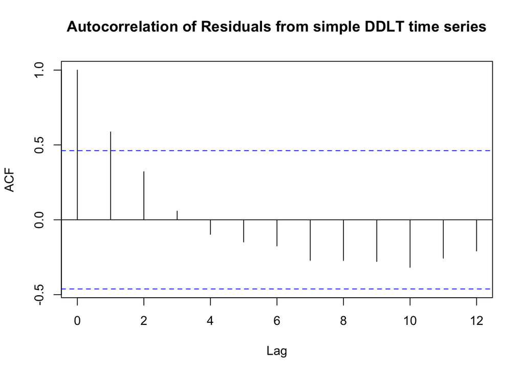

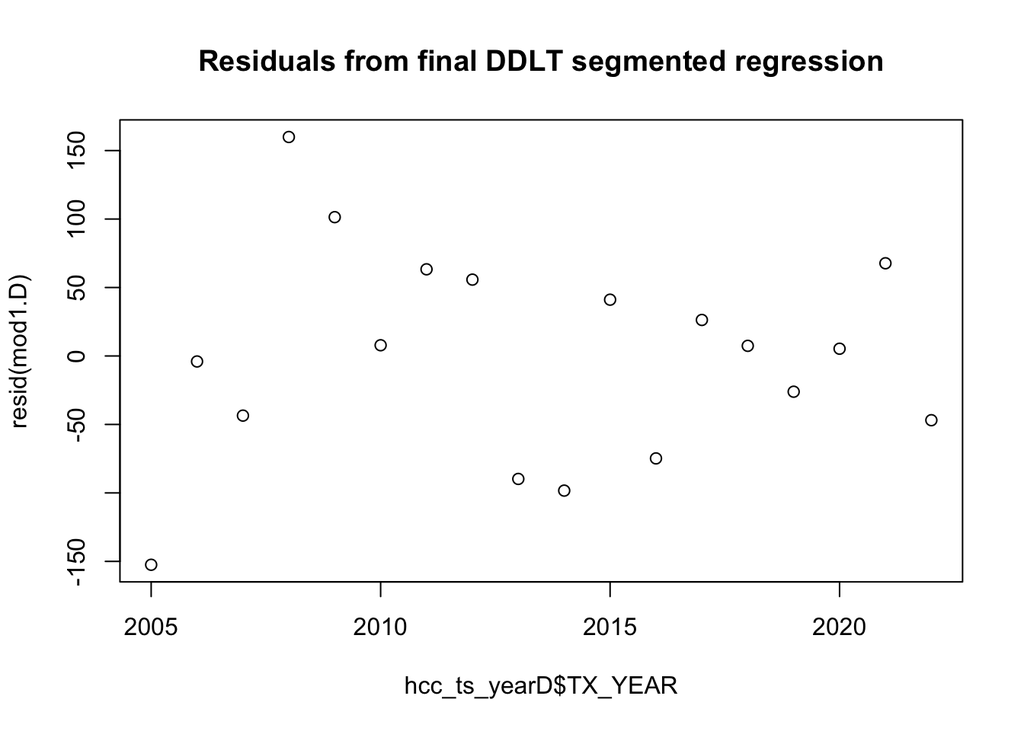

### Figure 2: Deceased Donor Liver Transplant Rates in Patients with HCC MELD exception over Pre-MMT era 1, Pre-MMT era 2, and MMT eras

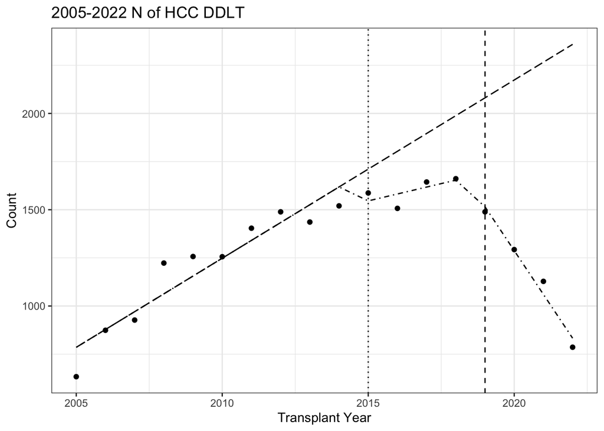

## Logistic Regression of Donor Type on covariates

Here we see that the AIC is minimized when allowing for an interaction between era and payment type, and era and region. Model results below.

Reference groups for predictors:

- Ethnicity - White
- Gender - Male
- Post 2019 - Pre
- Payment_new - Private
- Education - none to GED
- Region - Central

```
##                      Model      AIC
## 1             Main effects 4728.608
## 2               Era by Age 4730.565
## 3         Era by Ethnicity 4733.421
## 4               Era by BMI 4729.244
## 5        Era by Creatinine 4727.614
## 6            Era by Gender 4727.490
## 7             Era by Payer 4725.705
## 8        Era by Functional 4725.067
## 9         Era by Education 4730.046
## 10           Era by Region 4681.941
## 11 Era by Region and Payer 4678.870
```

Odds ratios and confidence intervals of having a Living Donor Transplant (See above for reference groups)

| Variable | OR | Lower 95% CI | Upper 95% CI |
| --- | --- | --- | --- |
| (Intercept) | 0.00 | 0.00 | 0.00 |
| AGE | 0.98 | 0.97 | 0.99 |
| Eth_NewAsian | 0.46 | 0.31 | 0.67 |
| Eth_NewHisp/Lat | 0.97 | 0.75 | 1.24 |
| Eth_NewNon Hisp Black | 0.28 | 0.17 | 0.44 |
| Eth_NewOther | 0.88 | 0.34 | 1.84 |
| BMI_CALC | 0.96 | 0.94 | 0.97 |
| MELD_PELD_LAB_SCORE | 1.00 | 0.98 | 1.01 |
| FINAL_SERUM_CREAT | 0.80 | 0.64 | 1.00 |
| GENDERFemale | 1.74 | 1.43 | 2.10 |
| Post2019Post | 1.60 | 0.56 | 4.04 |
| Payment_newPublic | 0.58 | 0.46 | 0.73 |
| FUNC_STAT_TRR | 1.01 | 1.01 | 1.02 |
| ED_newCollege | 1.31 | 1.08 | 1.57 |
| ED_newPost Grad | 1.88 | 1.40 | 2.50 |
| REG_newMidwest | 3.07 | 1.82 | 5.54 |
| REG_newNortheast | 3.83 | 2.32 | 6.82 |
| REG_newSouth | 0.40 | 0.22 | 0.78 |
| REG_newWestern | 1.47 | 0.85 | 2.70 |
| Post2019Post:Payment_newPublic | 1.52 | 1.06 | 2.20 |
| Post2019Post:REG_newMidwest | 0.56 | 0.20 | 1.73 |
| Post2019Post:REG_newNortheast | 1.40 | 0.54 | 4.09 |
| Post2019Post:REG_newSouth | 4.63 | 1.66 | 14.38 |
| Post2019Post:REG_newWestern | 0.64 | 0.22 | 2.02 |

#### Likelihood-ratio tests of all model predictors plus interactions from final interaction model.

Below, we see that all variables except MELD PELD a significant factors in the model

```
## Analysis of Deviance Table (Type II tests)
##
## Response: DON_TY
##                      LR Chisq Df Pr(>Chisq)
## AGE                    10.834  1  0.0009963 ***
## Eth_New                53.460  4  6.827e-11 ***
## BMI_CALC               28.457  1  9.578e-08 ***
## MELD_PELD_LAB_SCORE     0.218  1  0.6405216
## FINAL_SERUM_CREAT       4.013  1  0.0451628 *
## GENDER                 30.351  1  3.604e-08 ***
## Post2019               87.615  1  < 2.2e-16 ***
## Payment_new            17.160  1  3.436e-05 ***
## FUNC_STAT_TRR          21.839  1  2.966e-06 ***
## ED_new                 19.325  2  6.363e-05 ***
## REG_new               223.406  4  < 2.2e-16 ***
## Post2019:Payment_new    5.071  1  0.0243270 *
## Post2019:REG_new       54.835  4  3.519e-11 ***
## ---
## Signif. codes:  0 '***' 0.001 '**' 0.01 '*' 0.05 '.' 0.1 ' ' 1
```